# Final Assignment:

#### The aim of this project is to investigate the Following research questions:

##### 1- Is there any difference in the mean BMI values between males and females?

##### 2- Is there any difference in the mean BMI values between the two types of gender seperation?

##### 3- Assess the effect of BMI on Glucose and Cholestrol separately?

The data is collected from the Lifeline dataset including; "continious" and "complete". The "continious" data set referes to the case in which a person has been participated in both data collection times. While, the "complete" data set referes to the case in which a person has participated in one or both data collection times. In this study the continious data is considered. For more information please read the "Toolkit - Aletta Year Challenge 2022" pdf file.

The following steps are required to answer the above research questions:

part 1: Load and Clean the data

part 2: Merge the Dataframes

part 3: Data Visualization (map, bar plots, scatter plot, correlation and heat map)

part 4: Statistical Analysis (Question1 (2-sample ttest), Question2 (2-sample ttest), Question3 (ANOVA))

part 5: Deduction

```python
# pip install import-ipynb
```

```python
#import all neccessary packages and libraries
import pandas as pd
import numpy as np
import yaml

import folium
import geopandas as gpd
import panel as pn
import seaborn as sns

import scipy.stats as stats
from scipy.stats import shapiro

from bokeh.models import Slope
from bokeh.plotting import figure, show
from bokeh.io import output_notebook
from bokeh.models import ColumnDataSource, FactorRange
from bokeh.transform import factor_cmap

import matplotlib.pyplot as plt
from sklearn.linear_model import LinearRegression

import import_ipynb
import Summary_functions_and_code_clean_v11 as sf

output_notebook()
pn.extension()
```

```
importing Jupyter notebook from Summary_functions_and_code_clean_v11.ipynb
```

## Part 1: Load and Clean the data:

Config file by yaml has been used to load the 3 datasets.

```python
#load the .txt data and convert into csv

with open('config.yaml','r') as stream:
    config = yaml.safe_load(stream)

age = config['age']
zipcode = config['zipcode']
zipcode_general = config['zipcode_general']

df_age = pd.read_csv(age,sep=";",encoding = 'utf_16')
df_zipcode = pd.read_csv(zipcode,sep=";",encoding = 'utf_16')
df_zipcode_general = pd.read_csv(zipcode_general,sep=";",encoding = 'utf_16')
```

```python
def seperate_columns(df):

    df = df.columns.to_frame().T.append(df, ignore_index=True) #convert header to row
    df.columns = range(len(df.columns)) #number the column
    df = df[0].str.split('\t', expand=True) #split columns
    df.columns = df.iloc[0] # consider the first row as header
    df = df[1:] #eliminate first row which was the copy of header

    return df
```

#### Note:

In order to decide which two datasets should be merged, datasets and their columns are checked.

```python
df_zipcode = seperate_columns(df = df_zipcode)
display(df_zipcode.head(2))
print(df_zipcode.columns)
```

|  | ZIPCODE | GENDER | GROUP_SIZE_CAT | AGE_CAT | AGE_T1 | AGE_T2 | BMI_T1 | WEIGHT_T1 | HIP_T1 | WAIST_T1 | ... | V_SUM_T1 | D_SUM_T1 | LTE_SUM_T1 | LDI_SUM_T1 | LTE_SUM_T2 | LDI_SUM_T2 | NSES_YEAR | NSES | MENTAL_DISORDER_T1 | MENTAL_DISORDER_T2 |
| --- | --- | --- | --- | --- | --- | --- | --- | --- | --- | --- | --- | --- | --- | --- | --- | --- | --- | --- | --- | --- | --- |
| 1 | 7741 | 1 | 3 | 8 | 43,35 | 46,83 | 26,34 | 86,69 | 98,70 | 95,47 | ... | 17,56 | 28,04 | 1,25 | 2,28 | 0,82 | 1,90 | 2010,00 | -1,35 | 1,20 | 2,07 |
| 2 | 7741 | 2 | 4 | 8 | 42,85 | 46,45 | 26,19 | 74,33 | 101,16 | 89,40 | ... | 19,13 | 27,67 | 1,24 | 2,58 | 0,74 | 1,94 | 2009,98 | -1,35 | 2,91 | 1,56 |

2 rows × 73 columns

```
Index(['ZIPCODE', 'GENDER', 'GROUP_SIZE_CAT', 'AGE_CAT', 'AGE_T1', 'AGE_T2',
       'BMI_T1', 'WEIGHT_T1', 'HIP_T1', 'WAIST_T1', 'HEIGHT_T1', 'BMI_T2',
       'WEIGHT_T2', 'HIP_T2', 'WAIST_T2', 'HEIGHT_T2', 'EDUCATION_LOWER_T1',
       'EDUCATION_LOWER_T2', 'WORK_T1', 'WORK_T2', 'LOW_QUALITY_OF_LIFE_T1',
       'LOW_QUALITY_OF_LIFE_T2', 'DBP_T1', 'DBP_T2', 'HBF_T1', 'HBF_T2',
       'MAP_T1', 'MAP_T2', 'SBP_T1', 'SBP_T2', 'HTN_MED_T1', 'CHO_T1',
       'GLU_T1', 'CHO_T2', 'GLU_T2', 'RESPIRATORY_DISEASE_T1', 'PACKYEARS',
       'SMOKING', 'METABOLIC_DISORDER_T1', 'METABOLIC_DISORDER_T2', 'LLDS',
       'Quintile_LLDS', 'ALCOHOL_INTAKE_T1', 'KCAL_INTAKE_T1', 'MWK_VAL',
       'SCOR_VAL', 'MWK_NO_VAL', 'SCOR_NO_VAL', 'SPORTS_T1',
       'CYCLE_COMMUTE_T1', 'VOLUNTEER_T1', 'PREGNANCIES', 'OSTEOARTHRITIS_T1',
       'SLEEP_QUALITY', 'DIAG_CFS_CDC', 'DIAG_FIBROMYALGIA_ACR',
       'DIAG_IBS_ROME3', 'C_SUM_T1', 'A_SUM_T1', 'SC_SUM_T1', 'I_SUM_T1',
       'E_SUM_T1', 'SD_SUM_T1', 'V_SUM_T1', 'D_SUM_T1', 'LTE_SUM_T1',
       'LDI_SUM_T1', 'LTE_SUM_T2', 'LDI_SUM_T2', 'NSES_YEAR', 'NSES',
       'MENTAL_DISORDER_T1', 'MENTAL_DISORDER_T2'],
      dtype='object', name=0)
```

```python
df_zipcode_general = seperate_columns(df = df_zipcode_general)
display(df_zipcode_general.head(2))
print(df_zipcode_general.columns)
```

|  | ZIPCODE | GENDER_FEMALE | GENDER_MALE | GROUP_SIZE_CAT | AGE_CAT | AGE_T1 | AGE_T2 | BMI_T1 | WEIGHT_T1 | HIP_T1 | ... | V_SUM_T1 | D_SUM_T1 | LTE_SUM_T1 | LDI_SUM_T1 | LTE_SUM_T2 | LDI_SUM_T2 | NSES_YEAR | NSES | MENTAL_DISORDER_T1 | MENTAL_DISORDER_T2 |
| --- | --- | --- | --- | --- | --- | --- | --- | --- | --- | --- | --- | --- | --- | --- | --- | --- | --- | --- | --- | --- | --- |
| 1 | 7741 | 56,58 | 43,42 | 6 | 8 | 44,10 | 46,61 | 26,00 | 79,10 | 99,76 | ... | 18,34 | 28,08 | 1,20 | 2,41 | 0,78 | 1,92 | 2009,99 | -1,35 | 1,91 | 1,79 |
| 2 | 7742 | 57,92 | 42,08 | 4 | 8 | 42,83 | 45,44 | 26,29 | 80,80 | 100,48 | ... | 18,07 | 28,52 | 1,00 | 2,44 | 0,69 | 2,01 | 2009,98 | -1,20 | 1,85 | 2,43 |

2 rows × 74 columns

```
Index(['ZIPCODE', 'GENDER_FEMALE', 'GENDER_MALE', 'GROUP_SIZE_CAT', 'AGE_CAT',
       'AGE_T1', 'AGE_T2', 'BMI_T1', 'WEIGHT_T1', 'HIP_T1', 'HEIGHT_T1',
       'WAIST_T1', 'BMI_T2', 'WEIGHT_T2', 'HIP_T2', 'HEIGHT_T2', 'WAIST_T2',
       'EDUCATION_LOWER_T1', 'EDUCATION_LOWER_T2', 'WORK_T1', 'WORK_T2',
       'LOW_QUALITY_OF_LIFE_T1', 'LOW_QUALITY_OF_LIFE_T2', 'DBP_T1', 'DBP_T2',
       'HBF_T1', 'HBF_T2', 'MAP_T1', 'MAP_T2', 'SBP_T1', 'SBP_T2',
       'HTN_MED_T1', 'CHO_T1', 'GLU_T1', 'CHO_T2', 'GLU_T2',
       'RESPIRATORY_DISEASE_T1', 'PACKYEARS', 'SMOKING',
       'METABOLIC_DISORDER_T1', 'METABOLIC_DISORDER_T2', 'LLDS',
       'Quintile_LLDS', 'ALCOHOL_INTAKE_T1', 'KCAL_INTAKE_T1', 'MWK_VAL',
       'SCOR_VAL', 'MWK_NO_VAL', 'SCOR_NO_VAL', 'SPORTS_T1',
       'CYCLE_COMMUTE_T1', 'VOLUNTEER_T1', 'PREGNANCIES', 'OSTEOARTHRITIS_T1',
       'SLEEP_QUALITY', 'DIAG_CFS_CDC', 'DIAG_FIBROMYALGIA_ACR',
       'DIAG_IBS_ROME3', 'C_SUM_T1', 'A_SUM_T1', 'SC_SUM_T1', 'I_SUM_T1',
       'E_SUM_T1', 'SD_SUM_T1', 'V_SUM_T1', 'D_SUM_T1', 'LTE_SUM_T1',
       'LDI_SUM_T1', 'LTE_SUM_T2', 'LDI_SUM_T2', 'NSES_YEAR', 'NSES',
       'MENTAL_DISORDER_T1', 'MENTAL_DISORDER_T2'],
      dtype='object', name=0)
```

```python
df_age = seperate_columns(df = df_age)
display(df_age.head(2))
print(df_age.columns)
```

|  | AGE | GENDER | GROUP_SIZE_CAT | AGE_T1 | AGE_T2 | BMI_T1 | WEIGHT_T1 | HIP_T1 | WAIST_T1 | HEIGHT_T1 | ... | V_SUM_T1 | D_SUM_T1 | LTE_SUM_T1 | LDI_SUM_T1 | LTE_SUM_T2 | LDI_SUM_T2 | NSES_YEAR | NSES | MENTAL_DISORDER_T1 | MENTAL_DISORDER_T2 |
| --- | --- | --- | --- | --- | --- | --- | --- | --- | --- | --- | --- | --- | --- | --- | --- | --- | --- | --- | --- | --- | --- |
| 1 | 25 | 1 | 1 | 17,02 | 20,00 | 21,33 | 71,72 | 89,76 | 78,02 | 183,27 | ... | 18,14 | 26,19 | 0,83 | 1,88 | 0,57 | 2,30 | 2010,00 | -0,67 | 0,66 | 1,07 |
| 2 | 25 | 2 | 2 | 17,12 | 19,96 | 22,10 | 64,26 | 91,65 | 74,97 | 170,46 | ... | 20,49 | 26,52 | 0,85 | 3,13 | 0,66 | 3,37 | 2010,00 | -0,74 | 0,76 | 1,87 |

2 rows × 72 columns

```
Index(['AGE', 'GENDER', 'GROUP_SIZE_CAT', 'AGE_T1', 'AGE_T2', 'BMI_T1',
       'WEIGHT_T1', 'HIP_T1', 'WAIST_T1', 'HEIGHT_T1', 'BMI_T2', 'WEIGHT_T2',
       'HIP_T2', 'WAIST_T2', 'HEIGHT_T2', 'EDUCATION_LOWER_T1',
       'EDUCATION_LOWER_T2', 'WORK_T1', 'WORK_T2', 'LOW_QUALITY_OF_LIFE_T1',
       'LOW_QUALITY_OF_LIFE_T2', 'DBP_T1', 'DBP_T2', 'HBF_T1', 'HBF_T2',
       'MAP_T1', 'MAP_T2', 'SBP_T1', 'SBP_T2', 'HTN_MED_T1', 'CHO_T1',
       'GLU_T1', 'CHO_T2', 'GLU_T2', 'RESPIRATORY_DISEASE_T1', 'PACKYEARS',
       'SMOKING', 'METABOLIC_DISORDER_T1', 'METABOLIC_DISORDER_T2', 'LLDS',
       'Quintile_LLDS', 'ALCOHOL_INTAKE_T1', 'KCAL_INTAKE_T1', 'MWK_VAL',
       'SCOR_VAL', 'MWK_NO_VAL', 'SCOR_NO_VAL', 'SPORTS_T1',
       'CYCLE_COMMUTE_T1', 'VOLUNTEER_T1', 'PREGNANCIES', 'OSTEOARTHRITIS_T1',
       'SLEEP_QUALITY', 'DIAG_CFS_CDC', 'DIAG_FIBROMYALGIA_ACR',
       'DIAG_IBS_ROME3', 'C_SUM_T1', 'A_SUM_T1', 'SC_SUM_T1', 'I_SUM_T1',
       'E_SUM_T1', 'SD_SUM_T1', 'V_SUM_T1', 'D_SUM_T1', 'LTE_SUM_T1',
       'LDI_SUM_T1', 'LTE_SUM_T2', 'LDI_SUM_T2', 'NSES_YEAR', 'NSES',
       'MENTAL_DISORDER_T1', 'MENTAL_DISORDER_T2'],
      dtype='object', name=0)
```

### Which data is required:

ZIPCODE: Postal code 4 Baseline visit 1

GENDER: Gender (1=male, 2=female)

GENDER_MALE: Male participants in percentage

GENDER_FEMALE: Female participants in percentage

BMI_T1:Body Mass Index (kg/M^2) at baseline as mean (T1)

BMI_T2:Body Mass Index (kg/M^2) at baseline as mean (T2)

CHO_T1:Cholesterol (mmol/L) assessed on samples from baseline as mean (T1)

CHO_T2:Cholesterol (mmol/L) assessed on samples from second assessment second visit as mean (T2)

GLU_T1:Glucose (mmol/L) assessed on samples from baseline as mean (T1)

GLU_T2:Glucose (mmol/L) assessed on samples from second assessment secondvisit as mean (T2)

## Part 2: Merge dataframes

#### As data frames show, it is needed to merge two datasets based on 'ZIPCODE'.

So, zipcode and general datasets are merged based on ZIPCODE.

```python
# creat new dataframe from the required columns of 2 datasets
new_general = df_zipcode_general[['ZIPCODE','GENDER_FEMALE','GENDER_MALE','BMI_T1','BMI_T2','CHO_T1','CHO_T2','GLU_T1','GLU_T2']]
new_zip = df_zipcode[['ZIPCODE','GENDER','BMI_T1','BMI_T2','CHO_T1','CHO_T2','GLU_T1','GLU_T2']]
new_df = new_general.merge(new_zip,on= 'ZIPCODE', how = 'inner')
new_df.head()
```

|  | ZIPCODE | GENDER_FEMALE | GENDER_MALE | BMI_T1_x | BMI_T2_x | CHO_T1_x | CHO_T2_x | GLU_T1_x | GLU_T2_x | GENDER | BMI_T1_y | BMI_T2_y | CHO_T1_y | CHO_T2_y | GLU_T1_y | GLU_T2_y |
| --- | --- | --- | --- | --- | --- | --- | --- | --- | --- | --- | --- | --- | --- | --- | --- | --- |
| 0 | 7741 | 56,58 | 43,42 | 26,00 | 26,33 | 5,16 | 5,08 | 5,00 | 5,10 | 1 | 26,34 | 26,45 | 5,19 | 5,11 | 5,12 | 5,30 |
| 1 | 7741 | 56,58 | 43,42 | 26,00 | 26,33 | 5,16 | 5,08 | 5,00 | 5,10 | 2 | 26,19 | 26,24 | 5,07 | 5,06 | 4,93 | 4,95 |
| 2 | 7742 | 57,92 | 42,08 | 26,29 | 26,43 | 5,05 | 5,00 | 5,06 | 5,12 | 1 | 27,13 | 26,78 | 5,17 | 5,09 | 5,19 | 5,23 |
| 3 | 7742 | 57,92 | 42,08 | 26,29 | 26,43 | 5,05 | 5,00 | 5,06 | 5,12 | 2 | 26,01 | 26,18 | 4,91 | 4,93 | 4,94 | 5,04 |
| 4 | 7751 | 54,21 | 45,79 | 25,89 | 25,97 | 5,18 | 5,18 | 5,00 | 5,00 | 1 | 26,17 | 26,22 | 5,19 | 5,13 | 5,16 | 5,15 |

```python
# Check null data
new_df = new_df.replace(',','.',regex=True)
new_df = new_df.astype('float')
new_df.info()
```

```
<class 'pandas.core.frame.DataFrame'>
Int64Index: 661 entries, 0 to 660
Data columns (total 16 columns):
 #   Column         Non-Null Count  Dtype
---  ------         --------------  -----
 0   ZIPCODE        661 non-null    float64
 1   GENDER_FEMALE  661 non-null    float64
 2   GENDER_MALE    661 non-null    float64
 3   BMI_T1_x       661 non-null    float64
 4   BMI_T2_x       661 non-null    float64
 5   CHO_T1_x       661 non-null    float64
 6   CHO_T2_x       661 non-null    float64
 7   GLU_T1_x       661 non-null    float64
 8   GLU_T2_x       661 non-null    float64
 9   GENDER         661 non-null    float64
 10  BMI_T1_y       661 non-null    float64
 11  BMI_T2_y       661 non-null    float64
 12  CHO_T1_y       661 non-null    float64
 13  CHO_T2_y       661 non-null    float64
 14  GLU_T1_y       661 non-null    float64
 15  GLU_T2_y       661 non-null    float64
dtypes: float64(16)
memory usage: 87.8 KB
```

#### The title of the columns changed to an understandable names by the below function.

T1 and T2 refers to the time of data collection,

sex_% refers to the gender's seperation by percentage

sex_code refers to the gender's seperation by code (1=male, 2=female)

```python
def rename_columns(df = new_df):
    '''
    This function renames the name of columns
    parameter: new_df
    return: renamed new_df

    '''
    df.rename(columns={
        'BMI_T1_x': 'BMI_T1_sex_%',
        'BMI_T2_x': 'BMI_T2_sex_%',
        'BMI_T1_y': 'BMI_T1_sex_code',
        'BMI_T2_y': 'BMI_T2_sex_code',

        'GLU_T1_x': 'Glucose_T1_sex_%',
        'GLU_T2_x': 'Glucose_T2_sex_%',
        'GLU_T1_y': 'Glucose_T1_sex_code',
        'GLU_T2_y': 'Glucose_T2_sex_code',

        'CHO_T1_x': 'Cholestrol_T1_sex_%',
        'CHO_T2_x': 'Cholestrol_T2_sex_%',
        'CHO_T1_y': 'Cholestrol_T1_sex_code',
        'CHO_T2_y': 'Cholestrol_T2_sex_code'
        }, inplace=True)
    return df
new_df = rename_columns(df = new_df)
new_df.head()
```

|  | ZIPCODE | GENDER_FEMALE | GENDER_MALE | BMI_T1_sex_% | BMI_T2_sex_% | Cholestrol_T1_sex_% | Cholestrol_T2_sex_% | Glucose_T1_sex_% | Glucose_T2_sex_% | GENDER | BMI_T1_sex_code | BMI_T2_sex_code | Cholestrol_T1_sex_code | Cholestrol_T2_sex_code | Glucose_T1_sex_code | Glucose_T2_sex_code |
| --- | --- | --- | --- | --- | --- | --- | --- | --- | --- | --- | --- | --- | --- | --- | --- | --- |
| 0 | 7741.0 | 56.58 | 43.42 | 26.00 | 26.33 | 5.16 | 5.08 | 5.00 | 5.10 | 1.0 | 26.34 | 26.45 | 5.19 | 5.11 | 5.12 | 5.30 |
| 1 | 7741.0 | 56.58 | 43.42 | 26.00 | 26.33 | 5.16 | 5.08 | 5.00 | 5.10 | 2.0 | 26.19 | 26.24 | 5.07 | 5.06 | 4.93 | 4.95 |
| 2 | 7742.0 | 57.92 | 42.08 | 26.29 | 26.43 | 5.05 | 5.00 | 5.06 | 5.12 | 1.0 | 27.13 | 26.78 | 5.17 | 5.09 | 5.19 | 5.23 |
| 3 | 7742.0 | 57.92 | 42.08 | 26.29 | 26.43 | 5.05 | 5.00 | 5.06 | 5.12 | 2.0 | 26.01 | 26.18 | 4.91 | 4.93 | 4.94 | 5.04 |
| 4 | 7751.0 | 54.21 | 45.79 | 25.89 | 25.97 | 5.18 | 5.18 | 5.00 | 5.00 | 1.0 | 26.17 | 26.22 | 5.19 | 5.13 | 5.16 | 5.15 |

## Part 3: Data Visualization

### 3-1 : Show on map:

Here it has been shown which parts of the Netherlands are studied this research:

The blue border lines show the ZIPECODEs all over the Netherlands, while the red border lines show the ZIPECODEs of our research area.

```python
# Load the geojson data of the netherlands
netherland = gpd.read_file("https://public.opendatasoft.com/explore/dataset/georef-netherlands-postcode-pc4/download/?format=geojson&timezone=Europe/Berlin")
netherland = netherland[['pc4_code', 'geometry']]
```

```python
netherland.head()
```

|  | pc4_code | geometry |
| --- | --- | --- |
| 0 | 3297 | POLYGON ((4.59810 51.80724, 4.59805 51.80660, ... |
| 1 | 3352 | POLYGON ((4.68757 51.84818, 4.68878 51.84766, ... |
| 2 | 3361 | POLYGON ((4.74278 51.82948, 4.74265 51.82927, ... |
| 3 | 3362 | MULTIPOLYGON (((4.77415 51.82135, 4.77415 51.8... |
| 4 | 3455 | POLYGON ((5.00531 52.14321, 5.00548 52.14296, ... |

```python
# Change the format of zipecode in both dataframes
netherland['pc4_code'] = netherland['pc4_code'].astype(int)
new_df['ZIPCODE'] =new_df['ZIPCODE'].astype(int)

# merge the netherlands' data with new_df based on ZIPECODE and pc4_code
megre_NL_new_df = netherland.merge(new_df, left_on='pc4_code', right_on='ZIPCODE')
```

```python
# Initiation of dynamic map shown
mapobj = folium.Map(location =[52.09605484801253,4.28731872980122],zoom_start = 7)

# The zipecodes
borderstyle={'color':'blue','fill':False, 'weight':3}
folium.GeoJson(data = netherland, name='borders',style_function=lambda x:borderstyle).add_to(mapobj)
```

```
<folium.features.GeoJson at 0x10318567310>
```

```python
# The zipecodes
borderstyle1={'color':'red','fill':True, 'weight':3}
folium.GeoJson(data = megre_NL_new_df, name='borders', style_function=lambda x:borderstyle1).add_to(mapobj)
```

```
<folium.features.GeoJson at 0x10303bba700>
```

```python
# mapobj
```

### NOTE: 'mapobj' takes more capacity. So, it is commented now because, by this, it cannot be uploaded. But its image is in the image folder. To see the map, just uncomment the above cell.

### 3-2: Bar plots

```python
def bar_plot(target):
    '''
    This function illustrates Bar plot based on columns of data frame.
    parameters: name of columns of data frame
    return: bar plot based on ZIPCODE
    '''
    dff = new_df.groupby('ZIPCODE').mean()
    x = dff.index.values
    y = dff[target]
    p = figure(title = '', background_fill_color="lightgray",
               x_axis_label = 'ZIPCODE', y_axis_label = target,
               height=400, width=900)
    p.vbar(x, bottom=0,top= y, line_color='blue')

    return p

dff = new_df.groupby('ZIPCODE').mean()
targets = dff.columns[:]
inter_plot1 = pn.interact( bar_plot, target=targets)
inter_plot1
```

[interactive chart not shown]

```python
# bar plot:
def bar_plot_mean(df = new_df):
    '''
    This function calculate the mean of BMI, Cholestrol, and Glucose.
    Then returns Bar plot of means.
    parameter: new_df
    return: bar plot of mean
    '''

    Times = ['First data collection time', 'Second data collection time']
    factors = ['BMI(kg/M^2)', 'Glucose((mmol/L)', 'Cholesterol((mmol/L)']
    BMI =list(); CHO = list(); GLU = list()
    BMI.append((new_df[ 'BMI_T1_sex_code'].mean()+ new_df[ 'BMI_T1_sex_%'].mean())/2)
    BMI.append((new_df['BMI_T2_sex_code'].mean()+ new_df[ 'BMI_T2_sex_%'].mean())/2)

    CHO.append((new_df[ 'Cholestrol_T1_sex_code'].mean()+ new_df[ 'Cholestrol_T1_sex_%'].mean())/2)
    CHO.append((new_df[ 'Cholestrol_T2_sex_code'].mean()+ new_df[ 'Cholestrol_T2_sex_%'].mean())/2)

    GLU.append((new_df['Glucose_T1_sex_code'].mean()+ new_df['Glucose_T1_sex_%'].mean())/2)
    GLU.append((new_df[ 'Glucose_T2_sex_code'].mean()+ new_df['Glucose_T2_sex_%'].mean())/2)

    data = {'Time' : Times,
            'BMI'   : BMI,
            'Glucose'   : GLU,
            'Cholesterol'   : CHO}

    palette = ["#c9d9d3", "#718dbf", "#e84d60"]

    # this creates [ ("BMI", "T1"), ("BMI", "T2"), ("Glucose", "T1"), ("Glucose", "T2"), ... ]
    x = [ (time, factor) for time in Times for factor in factors ]
    counts = sum(zip(data['BMI'], data['Glucose'], data['Cholesterol']), ()) # like an hstack

    source = ColumnDataSource(data=dict(x=x, counts=counts))

    p = figure(x_range=FactorRange(*x), height=400, width=900,
               title="Mean of BMI, Glucose, and Cholesterol in both data collection times",
               y_axis_label="Mean",
               toolbar_location=None, tools="")

    p.vbar(x='x', top='counts', width=0.9, source=source, line_color="white",
           fill_color=factor_cmap('x', palette=palette, factors=factors, start=1, end=2))

    p.y_range.start = 0
    p.x_range.range_padding = 0.1
    p.xaxis.major_label_orientation = 1
    p.xgrid.grid_line_color = None

    return p

show(bar_plot_mean(df = new_df))
```

[interactive chart not shown]

### 3-3: Scatter plot:

```python
# scatter plot

def scatter_plot(time = 'time 1', gender_seperation ='percentage'):
    '''
    This function returns scatter plot based on BMI,Glucose, and Cholestrol.
    There is two data collection times, and two data collection ways.
    parameters: time: time1,time2
                gender seperation: percentage,code
    return: scatter plot
    '''

    if time =='time 1' and gender_seperation =='percentage':
        x = np.array(new_df['BMI_T1_sex_%'])
        y1 = np.array(new_df['Glucose_T1_sex_%'])
        y2 = np.array(new_df['Cholestrol_T1_sex_%'])
    if time =='time 1' and gender_seperation =='code':
        x = np.array(new_df[ 'BMI_T1_sex_code'])
        y1 = np.array(new_df['Glucose_T1_sex_code'])
        y2 = np.array(new_df['Cholestrol_T1_sex_code'])

    if time =='time 2' and gender_seperation =='percentage':
        x = np.array(new_df[ 'BMI_T2_sex_%'])
        y1 = np.array(new_df[ 'Glucose_T2_sex_%'])
        y2 = np.array(new_df['Cholestrol_T2_sex_%'])

    if time =='time 2' and gender_seperation =='code':
        x = np.array(new_df[ 'BMI_T2_sex_code'])
        y1 = np.array(new_df[ 'Glucose_T2_sex_code'])
        y2 = np.array(new_df[ 'Cholestrol_T2_sex_code'])


    # Regression model of each pair (BMI/Glucose and BMI/Cholesterol)
    # Make and fit a linear regression model
    model1 = LinearRegression().fit(x.reshape(-1, 1), y1)
    model2 = LinearRegression().fit(x.reshape(-1, 1), y2)
    # x values need to be in a two-dimensional array, so use .reshape(-1, 1)

    # Find the slope and intercept from the model
    slope1 = model1.coef_[0] # Takes the first element of the array
    slope2 = model2.coef_[0]

    intercept1 = model1.intercept_
    intercept2 = model2.intercept_

    # Make the regression line
    regression_line1 = Slope(gradient=slope1, y_intercept=intercept1, line_color="red", line_width=2)
    regression_line2 = Slope(gradient=slope2, y_intercept=intercept2, line_color="Blue", line_width=2)


    p = figure(title = 'Glucose and Cholesterol over BMI in '+ time,
               x_axis_label = 'BMI(kg/M^2)',y_axis_label = 'Glucose/Cholesterol ((mmol/L)',
               background_fill_color="white", height=500, width=900)

    p.circle(x,y1,color = 'red', size=8, legend_label = 'Glucose')
    p.circle(x,y2,color = 'blue', size=8, legend_label = 'Cholesterol')

    p.add_layout(regression_line1)
    p.add_layout(regression_line2)

    return p

times = ['time 1','time 2']
gender_seperations =['percentage','code']
inter_plot2 = pn.interact(scatter_plot,time = times, gender_seperation = gender_seperations)
inter_plot2
```

[interactive chart not shown]

### 3-4: Correlation and Heat map:

To identify a relation between two variables and how they influence each other, a correlation study is essential. Therefor, for these data frames,the correlation between cholesterol, glucose, and BMI has been obtained.(The Correlation tables based on gender seperation is calculated)

Then, to visualize the correlation, a heatmap from the seaborn galley used.

```python
df1 = new_df[['BMI_T1_sex_%','BMI_T2_sex_%','Cholestrol_T1_sex_%',
             'Cholestrol_T2_sex_%','Glucose_T1_sex_%','Glucose_T2_sex_%']]
correlation1 = df1.corr()

df2 = new_df[['BMI_T1_sex_code','BMI_T2_sex_code','Cholestrol_T1_sex_code',
             'Cholestrol_T2_sex_code','Glucose_T1_sex_code','Glucose_T2_sex_code']]
correlation2 = df2.corr()

display(correlation1)
display(correlation2)
```

| 0 | BMI_T1_sex_% | BMI_T2_sex_% | Cholestrol_T1_sex_% | Cholestrol_T2_sex_% | Glucose_T1_sex_% | Glucose_T2_sex_% |
| --- | --- | --- | --- | --- | --- | --- |
| BMI_T1_sex_% | 1.000000 | 0.963600 | 0.250265 | 0.125785 | 0.590311 | 0.612505 |
| BMI_T2_sex_% | 0.963600 | 1.000000 | 0.221481 | 0.149936 | 0.557206 | 0.598079 |
| Cholestrol_T1_sex_% | 0.250265 | 0.221481 | 1.000000 | 0.775466 | 0.159857 | 0.139884 |
| Cholestrol_T2_sex_% | 0.125785 | 0.149936 | 0.775466 | 1.000000 | 0.102466 | 0.063665 |
| Glucose_T1_sex_% | 0.590311 | 0.557206 | 0.159857 | 0.102466 | 1.000000 | 0.830845 |
| Glucose_T2_sex_% | 0.612505 | 0.598079 | 0.139884 | 0.063665 | 0.830845 | 1.000000 |

| 0 | BMI_T1_sex_code | BMI_T2_sex_code | Cholestrol_T1_sex_code | Cholestrol_T2_sex_code | Glucose_T1_sex_code | Glucose_T2_sex_code |
| --- | --- | --- | --- | --- | --- | --- |
| BMI_T1_sex_code | 1.000000 | 0.909104 | 0.304569 | 0.110658 | 0.475566 | 0.474936 |
| BMI_T2_sex_code | 0.909104 | 1.000000 | 0.267651 | 0.142678 | 0.418321 | 0.471383 |
| Cholestrol_T1_sex_code | 0.304569 | 0.267651 | 1.000000 | 0.660206 | 0.311472 | 0.272042 |
| Cholestrol_T2_sex_code | 0.110658 | 0.142678 | 0.660206 | 1.000000 | -0.057360 | -0.051415 |
| Glucose_T1_sex_code | 0.475566 | 0.418321 | 0.311472 | -0.057360 | 1.000000 | 0.873979 |
| Glucose_T2_sex_code | 0.474936 | 0.471383 | 0.272042 | -0.051415 | 0.873979 | 1.000000 |

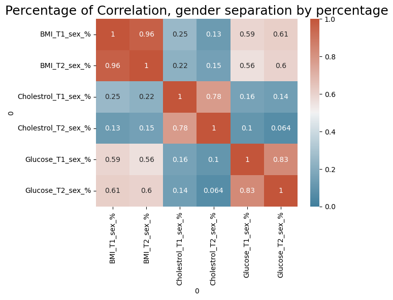

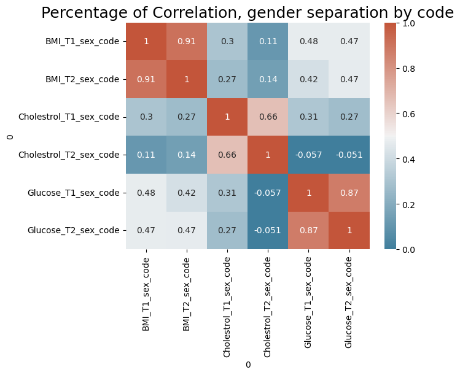

```python
def correlation_heatmap(df, gender_seperation='code'):
    '''
    This function has dataframes and by means of seaborn gallery shown heat maps
    '''
    # Generate a custom diverging colormap
    cmap = sns.diverging_palette(230, 20, as_cmap=True)

    # calculate correlation
    correlation = df.corr()

    # plot heatmap by seaborn gallery
    plt.title('Percentage of Correlation, gender separation by '+ gender_seperation , fontsize=18)
    sns.heatmap(correlation, annot = True, cmap=cmap, vmin=0, vmax=1)
    plt.show()

correlation_heatmap(df= df1,gender_seperation = 'percentage' )
correlation_heatmap(df= df2, gender_seperation = 'code')
```

#### Note:

The heat maps show that the BMI has more influence on Glucose than Cholestrol. According to the first heat map, during first data collection, the influence of BMI on Glucose was 59% by BMI, whereas in the second data collection time, it was 60%.

However, based on the second heat map, in the first and second data collection, Glucose is influenced 48% and 47% by BMI, respectively.

In contrast, in the both heat maps, BMI has lower effect on Cholestrol.

## Part4: Statistical Analysis:

### 4-1: Question1:

#### Is there any difference in the mean BMI values between males and females?

To answer the research question properly, at first the normality of BMI values should be tested.

```python
male_df = new_df[new_df['GENDER']==1]
female_df = new_df[new_df['GENDER']==2]
```

```
Estimation method: robust
mu = 26.02, sigma = 0.6838
```

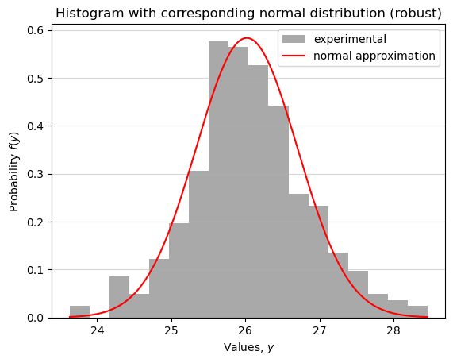

```
Estimation method: robust
mu = 26.07, sigma = 0.7524
```

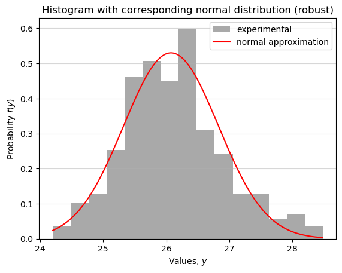

```
Estimation method: robust
mu = 25.68, sigma = 0.8895
```

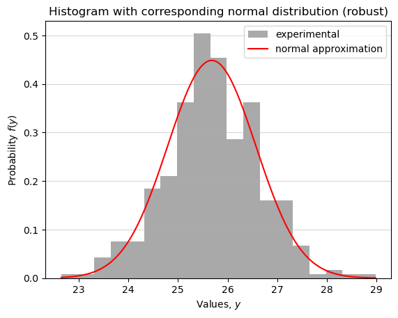

```
Estimation method: robust
mu = 25.82, sigma = 0.8228
```

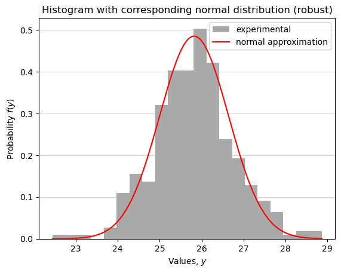

```python
#Check Normality of BMI for men and women by Q-Q Hist plot
sf.DS_Q_Q_Hist(male_df['BMI_T1_sex_code'])
sf.DS_Q_Q_Hist(male_df['BMI_T2_sex_code'])
sf.DS_Q_Q_Hist(female_df['BMI_T1_sex_code'])
sf.DS_Q_Q_Hist(female_df['BMI_T2_sex_code'])
```

```
Estimation method: robust
n = 304, mu = 26.02, sigma = 0.6838
Expected number of data outside CI: 15
```

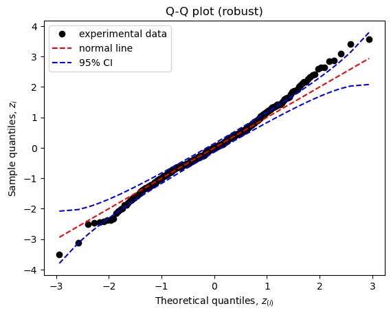

```
Estimation method: robust
n = 304, mu = 26.07, sigma = 0.7524
Expected number of data outside CI: 15
```

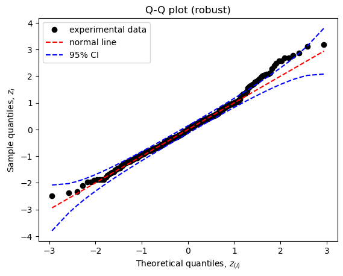

```
Estimation method: robust
n = 357, mu = 25.68, sigma = 0.8895
Expected number of data outside CI: 18
```

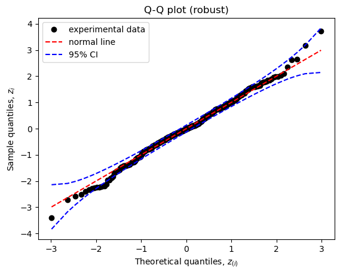

```
Estimation method: robust
n = 357, mu = 25.68, sigma = 0.8895
Expected number of data outside CI: 18
```

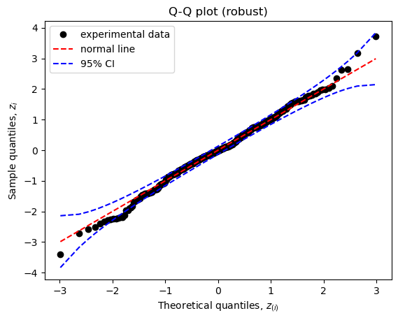

```python
#Check Normality of BMI for men and women by Q-Q plot
sf. DS_Q_Q_Plot(male_df['BMI_T1_sex_code'])
sf. DS_Q_Q_Plot(male_df['BMI_T2_sex_code'])
sf. DS_Q_Q_Plot(female_df['BMI_T1_sex_code'])
sf. DS_Q_Q_Plot(female_df['BMI_T1_sex_code'])
```

#### Note:

The plots show that most of the data points are in the confidence interval. Therefore, BMI values for men and women are normally distributed. Now, 2-sample t-test could be applied.

```python
sf.DS_2sample_ttest_means(male_df['BMI_T1_sex_code'], female_df['BMI_T1_sex_code'], alternative='two-sided', alpha=0.05)
```

```
--------------------------------------------------------------------------------
Welch t-test for 2 means:
     assuming Normal(mu.1, sigma2.1) data for dataset 1
     assuming Normal(mu.2, sigma2.2) data for dataset 2
y.av.1 = 26.1, y.av.2 = 25.7, s2.1 = 0.614, s2.2 = 0.882, n.1 = 304, n.2 = 357, alpha = 0.05
H0: mu.1  = mu.2
H1: mu.1 != mu.2
t = 5.478, p-value = 6.134e-08, t.crit.L = -1.964, t.crit.R = 1.964, df = 658.7
Effect size: d.av = 0.427; benchmarks |d.av|: 0.2 = small, 0.5 = medium, 0.8 = large
--------------------------------------------------------------------------------
```

```
(5.477789865570586,
 6.133829589920682e-08,
 -1.9635717688345191,
 1.9635717688345187)
```

```python
sf.DS_2sample_ttest_means(male_df['BMI_T2_sex_code'], female_df['BMI_T2_sex_code'], alternative='two-sided', alpha=0.05)
```

```
--------------------------------------------------------------------------------
Welch t-test for 2 means:
     assuming Normal(mu.1, sigma2.1) data for dataset 1
     assuming Normal(mu.2, sigma2.2) data for dataset 2
y.av.1 = 26.1, y.av.2 = 25.8, s2.1 = 0.635, s2.2 = 0.899, n.1 = 304, n.2 = 357, alpha = 0.05
H0: mu.1  = mu.2
H1: mu.1 != mu.2
t = 4.263, p-value = 2.309e-05, t.crit.L = -1.964, t.crit.R = 1.964, df = 658.9
Effect size: d.av = 0.333; benchmarks |d.av|: 0.2 = small, 0.5 = medium, 0.8 = large
--------------------------------------------------------------------------------
```

```
(4.263232539403887,
 2.309420773048624e-05,
 -1.9635709020609138,
 1.9635709020609133)
```

#### Answer:

Both p_values are less than 0.05. It means that there is a significant difference in mean BMI values between males and females.

### 4-2: Question2:

#### Is there any difference in the mean BMI values between the two types of gender seperation?

To answer this question, at first, Normality of BMI values should be tested.

```
Estimation method: robust
mu = 25.83, sigma = 0.7784
```

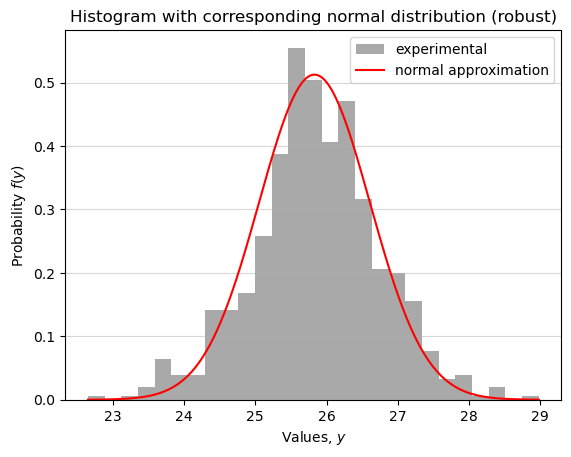

```
Estimation method: robust
mu = 25.93, sigma = 0.7858
```

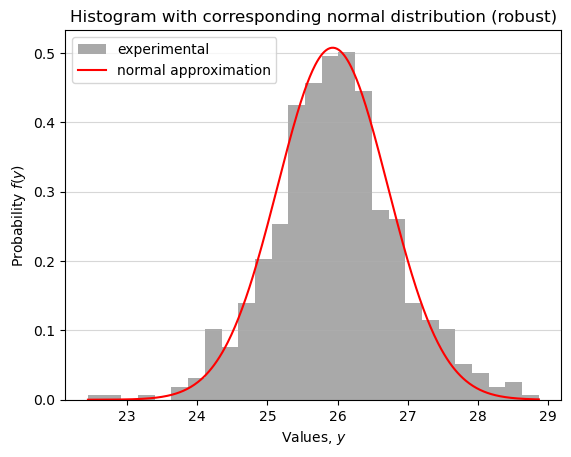

```
Estimation method: robust
mu = 25.77, sigma = 0.7413
```

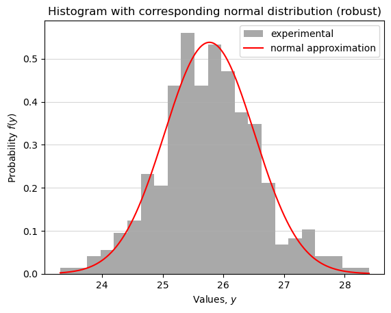

```
Estimation method: robust
mu = 25.96, sigma = 0.7858
```

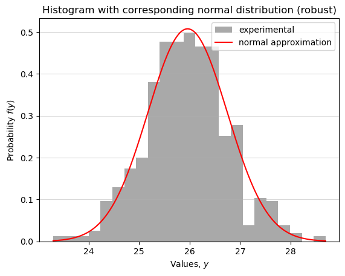

```python
sf.DS_Q_Q_Hist(new_df['BMI_T1_sex_code'])
sf.DS_Q_Q_Hist(new_df['BMI_T2_sex_code'])
sf.DS_Q_Q_Hist(new_df['BMI_T1_sex_%'])
sf.DS_Q_Q_Hist(new_df['BMI_T2_sex_%'])
```

```
Estimation method: robust
n = 661, mu = 25.83, sigma = 0.7784
Expected number of data outside CI: 33
```

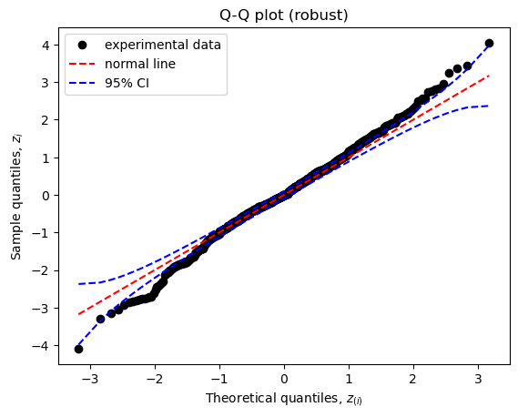

```
Estimation method: robust
n = 661, mu = 25.93, sigma = 0.7858
Expected number of data outside CI: 33
```

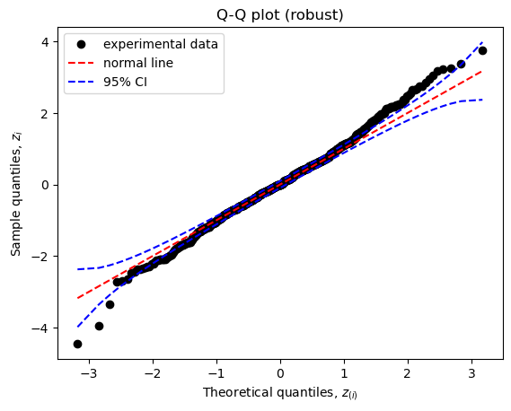

```
Estimation method: robust
n = 661, mu = 25.77, sigma = 0.7413
Expected number of data outside CI: 33
```

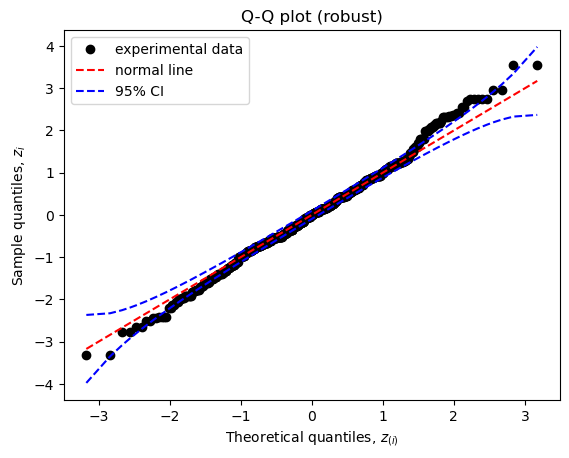

```
Estimation method: robust
n = 661, mu = 25.96, sigma = 0.7858
Expected number of data outside CI: 33
```

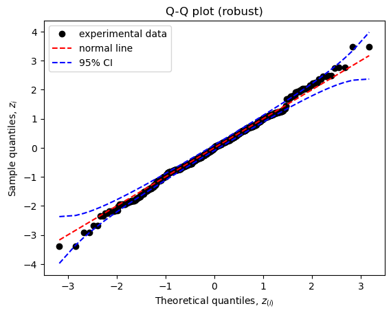

```python
sf.DS_Q_Q_Plot(new_df['BMI_T1_sex_code'])
sf.DS_Q_Q_Plot(new_df['BMI_T2_sex_code'])
sf.DS_Q_Q_Plot(new_df['BMI_T1_sex_%'])
sf.DS_Q_Q_Plot(new_df['BMI_T2_sex_%'])
```

#### Note:

The plots show that most of the data points are in the confidence interval. Therefore, BMI values for gender depration methods are normally distributed. Now, 2-sample t-test could be applied.

```python
sf.DS_2sample_ttest_means(new_df['BMI_T1_sex_code'], new_df['BMI_T1_sex_%'], alternative='two-sided', alpha=0.05)
```

```
--------------------------------------------------------------------------------
Welch t-test for 2 means:
     assuming Normal(mu.1, sigma2.1) data for dataset 1
     assuming Normal(mu.2, sigma2.2) data for dataset 2
y.av.1 = 25.9, y.av.2 = 25.8, s2.1 = 0.791, s2.2 = 0.659, n.1 = 661, n.2 = 661, alpha = 0.05
H0: mu.1  = mu.2
H1: mu.1 != mu.2
t = 1.839, p-value = 0.06618, t.crit.L = -1.962, t.crit.R = 1.962, df = 1309
Effect size: d.av = 0.101; benchmarks |d.av|: 0.2 = small, 0.5 = medium, 0.8 = large
--------------------------------------------------------------------------------
```

```
(1.8387644450480147,
 0.06617623553356844,
 -1.9617777397827691,
 1.9617777397827687)
```

```python
sf.DS_2sample_ttest_means(new_df['BMI_T2_sex_code'], new_df['BMI_T2_sex_%'], alternative='two-sided', alpha=0.05)
```

```
--------------------------------------------------------------------------------
Welch t-test for 2 means:
     assuming Normal(mu.1, sigma2.1) data for dataset 1
     assuming Normal(mu.2, sigma2.2) data for dataset 2
y.av.1 = 26, y.av.2 = 25.9, s2.1 = 0.798, s2.2 = 0.674, n.1 = 661, n.2 = 661, alpha = 0.05
H0: mu.1  = mu.2
H1: mu.1 != mu.2
t = 0.2754, p-value = 0.7831, t.crit.L = -1.962, t.crit.R = 1.962, df = 1311
Effect size: d.av = 0.0151; benchmarks |d.av|: 0.2 = small, 0.5 = medium, 0.8 = large
--------------------------------------------------------------------------------
```

```
(0.2753884949384075,
 0.7830611846454208,
 -1.961775373627617,
 1.9617753736276164)
```

#### Answer:

Both p_values are greater than 0.05. It means that there is NO significant difference in mean BMI values between two gender seperation methods.

### 4-3: Question3:

#### Assess the effect of BMI on Glucose and Cholestrol separately?

To answer this question, the following steps need to be used:

1- Normality

2- Homogeneity of Variance

3- ANOVA

#### 4-3-1: Test of Normality:

At first BMI values should be categorized. After that, to check the Normality, the Shapiro-Wilk normality test should be used.

```python
def categorical_BMI(df = new_df.copy()):
    '''
    This function classified BMI based on the following:
    18.5 to 25: Normal weight
    25 to 27: Slightly overweight
    27 to 30: Moderately overweight
    parameter: dataframe
    return: dataframe contained categorized BMI
    '''

    BMI_list = ['BMI_T1_sex_%','BMI_T1_sex_code','BMI_T2_sex_%','BMI_T2_sex_code']
    for i in BMI_list:

        normal = np.array(df[df[i].between(18,25)][i])
        s_overweight = np.array(df[df[i].between(25, 27)][i])
        m_overweight = np.array(df[df[i].between(27, 30)][i])

        df[i] = df[i].replace (normal, 'Normal weight')
        df[i] = df[i].replace (s_overweight, 'Slightly overweight')
        df[i] = df[i].replace (m_overweight, 'Moderately overweight')

    return df

categorical_df = categorical_BMI(df = new_df.copy())
categorical_df.head()
```

|  | ZIPCODE | GENDER_FEMALE | GENDER_MALE | BMI_T1_sex_% | BMI_T2_sex_% | Cholestrol_T1_sex_% | Cholestrol_T2_sex_% | Glucose_T1_sex_% | Glucose_T2_sex_% | GENDER | BMI_T1_sex_code | BMI_T2_sex_code | Cholestrol_T1_sex_code | Cholestrol_T2_sex_code | Glucose_T1_sex_code | Glucose_T2_sex_code |
| --- | --- | --- | --- | --- | --- | --- | --- | --- | --- | --- | --- | --- | --- | --- | --- | --- |
| 0 | 7741 | 56.58 | 43.42 | Slightly overweight | Slightly overweight | 5.16 | 5.08 | 5.00 | 5.10 | 1.0 | Slightly overweight | Slightly overweight | 5.19 | 5.11 | 5.12 | 5.30 |
| 1 | 7741 | 56.58 | 43.42 | Slightly overweight | Slightly overweight | 5.16 | 5.08 | 5.00 | 5.10 | 2.0 | Slightly overweight | Slightly overweight | 5.07 | 5.06 | 4.93 | 4.95 |
| 2 | 7742 | 57.92 | 42.08 | Slightly overweight | Slightly overweight | 5.05 | 5.00 | 5.06 | 5.12 | 1.0 | Moderately overweight | Slightly overweight | 5.17 | 5.09 | 5.19 | 5.23 |
| 3 | 7742 | 57.92 | 42.08 | Slightly overweight | Slightly overweight | 5.05 | 5.00 | 5.06 | 5.12 | 2.0 | Slightly overweight | Slightly overweight | 4.91 | 4.93 | 4.94 | 5.04 |
| 4 | 7751 | 54.21 | 45.79 | Slightly overweight | Slightly overweight | 5.18 | 5.18 | 5.00 | 5.00 | 1.0 | Slightly overweight | Slightly overweight | 5.19 | 5.13 | 5.16 | 5.15 |

```python
def shapiro_wilk(df = new_df.copy()):
    '''
    This function test Normality of the data by shapiro_wilk test.
    parameters: df = new_df
    returns: two lists: one for normal data, the other for not normal data
    '''

    BMI_GLU_CHO_list = [['Glucose_T1_sex_%','BMI_T1_sex_%'],['Glucose_T2_sex_%','BMI_T2_sex_%'],
                   ['Glucose_T1_sex_code','BMI_T1_sex_code'],['Glucose_T2_sex_code','BMI_T2_sex_code'],
                   ['Cholestrol_T1_sex_%','BMI_T1_sex_%'],['Cholestrol_T2_sex_%','BMI_T2_sex_%'],
                   ['Cholestrol_T1_sex_code','BMI_T1_sex_code'],['Cholestrol_T2_sex_code','BMI_T2_sex_code']]
    BMI_kinds = ['Normal weight','Slightly overweight','Moderately overweight']
    normal =[]
    not_normal =[]
    for i, j in BMI_GLU_CHO_list:
        for k in BMI_kinds:
            statistic, pvalue = shapiro(categorical_df[categorical_df[j] == k][i])
            print (i,'_',j,'In BMI category of',k, 'P_value: ',pvalue)
            if pvalue<0.05:
                print ('pvalue is less than 0.05, so the data tested are NOT normally distributed\n')
                not_normal.append([i,j,k])
            if pvalue>0.05:
                print ('pvalue is greater than 0.05, so the data tested ARE normally distributed\n')
                normal.append([i,j,k])
    return normal,not_normal
normal, not_normal = shapiro_wilk(df = new_df.copy())
```

```
Glucose_T1_sex_% _ BMI_T1_sex_% In BMI category of Normal weight P_value:  0.08428292721509933
pvalue is greater than 0.05, so the data tested ARE normally distributed

Glucose_T1_sex_% _ BMI_T1_sex_% In BMI category of Slightly overweight P_value:  0.0002790272410493344
pvalue is less than 0.05, so the data tested are NOT normally distributed

Glucose_T1_sex_% _ BMI_T1_sex_% In BMI category of Moderately overweight P_value:  0.2739853858947754
pvalue is greater than 0.05, so the data tested ARE normally distributed

Glucose_T2_sex_% _ BMI_T2_sex_% In BMI category of Normal weight P_value:  0.29992714524269104
pvalue is greater than 0.05, so the data tested ARE normally distributed

Glucose_T2_sex_% _ BMI_T2_sex_% In BMI category of Slightly overweight P_value:  2.326396952412324e-06
pvalue is less than 0.05, so the data tested are NOT normally distributed

Glucose_T2_sex_% _ BMI_T2_sex_% In BMI category of Moderately overweight P_value:  0.1414792537689209
pvalue is greater than 0.05, so the data tested ARE normally distributed

Glucose_T1_sex_code _ BMI_T1_sex_code In BMI category of Normal weight P_value:  0.01481573935598135
pvalue is less than 0.05, so the data tested are NOT normally distributed

Glucose_T1_sex_code _ BMI_T1_sex_code In BMI category of Slightly overweight P_value:  5.1947392165629935e-08
pvalue is less than 0.05, so the data tested are NOT normally distributed

Glucose_T1_sex_code _ BMI_T1_sex_code In BMI category of Moderately overweight P_value:  0.028251029551029205
pvalue is less than 0.05, so the data tested are NOT normally distributed

Glucose_T2_sex_code _ BMI_T2_sex_code In BMI category of Normal weight P_value:  0.3058684170246124
pvalue is greater than 0.05, so the data tested ARE normally distributed

Glucose_T2_sex_code _ BMI_T2_sex_code In BMI category of Slightly overweight P_value:  0.00205274042673409
pvalue is less than 0.05, so the data tested are NOT normally distributed

Glucose_T2_sex_code _ BMI_T2_sex_code In BMI category of Moderately overweight P_value:  0.029256660491228104
pvalue is less than 0.05, so the data tested are NOT normally distributed

Cholestrol_T1_sex_% _ BMI_T1_sex_% In BMI category of Normal weight P_value:  0.0001576603390276432
pvalue is less than 0.05, so the data tested are NOT normally distributed

Cholestrol_T1_sex_% _ BMI_T1_sex_% In BMI category of Slightly overweight P_value:  2.390549889241811e-05
```

[output cut: 16 more lines]

```

Cholestrol_T1_sex_code _ BMI_T1_sex_code In BMI category of Slightly overweight P_value:  0.12897400557994843
pvalue is greater than 0.05, so the data tested ARE normally distributed

Cholestrol_T1_sex_code _ BMI_T1_sex_code In BMI category of Moderately overweight P_value:  0.1535627841949463
pvalue is greater than 0.05, so the data tested ARE normally distributed

Cholestrol_T2_sex_code _ BMI_T2_sex_code In BMI category of Normal weight P_value:  0.6638658046722412
pvalue is greater than 0.05, so the data tested ARE normally distributed

Cholestrol_T2_sex_code _ BMI_T2_sex_code In BMI category of Slightly overweight P_value:  3.142075115647458e-07
pvalue is less than 0.05, so the data tested are NOT normally distributed

Cholestrol_T2_sex_code _ BMI_T2_sex_code In BMI category of Moderately overweight P_value:  0.33743008971214294
pvalue is greater than 0.05, so the data tested ARE normally distributed
```

```python
categorical_df.skew(numeric_only=True)
```

```
0
ZIPCODE                  -0.560307
GENDER_FEMALE             0.141955
GENDER_MALE              -0.142005
Cholestrol_T1_sex_%       0.070881
Cholestrol_T2_sex_%      -0.178796
Glucose_T1_sex_%          0.301957
Glucose_T2_sex_%          0.306208
GENDER                   -0.161247
Cholestrol_T1_sex_code    0.009138
Cholestrol_T2_sex_code   -0.287020
Glucose_T1_sex_code       0.222669
Glucose_T2_sex_code       0.267548
dtype: float64
```

#### 4-3-2: Test of Homogeneity of Variance:

The equality of variance in all groups should be assessed by Levene or Bartlett test. Leven test is used for non_normal data, and Bartlett test is used for normal data. Since we have both Normal and non_normal data, both Bartlett and Leven tests need to be used to test the homogeneity of variance.

```python
def Homogeneity_bartlett_test():
    '''
    This function tests the equality of variances in all groups.
    If the Bartlett test shows p_values greater than 0.05, so the variances are equal,
    else they are not equal.
    '''
    for i, j, k in normal:
        statistic, pvalue = stats.bartlett(categorical_df[i][categorical_df[j] == 'Normal weight'],
                     categorical_df[i][categorical_df[j] == 'Slightly overweight'],
                     categorical_df[i][categorical_df[j] == 'Moderately overweight'])
        print (i,'_',j,'In BMI category of',k, 'P_value: ',pvalue)
        if pvalue<0.05:
            print ('pvalue is less than 0.05, so all groups have NOT equal variance\n')
        if pvalue>0.05:
            print ('pvalue is greater than 0.05, so all groups HAVE equal variance\n')

Homogeneity_bartlett_test()
```

```
Glucose_T1_sex_% _ BMI_T1_sex_% In BMI category of Normal weight P_value:  0.1898471699174439
pvalue is greater than 0.05, so all groups HAVE equal variance

Glucose_T1_sex_% _ BMI_T1_sex_% In BMI category of Moderately overweight P_value:  0.1898471699174439
pvalue is greater than 0.05, so all groups HAVE equal variance

Glucose_T2_sex_% _ BMI_T2_sex_% In BMI category of Normal weight P_value:  0.3586043603557172
pvalue is greater than 0.05, so all groups HAVE equal variance

Glucose_T2_sex_% _ BMI_T2_sex_% In BMI category of Moderately overweight P_value:  0.3586043603557172
pvalue is greater than 0.05, so all groups HAVE equal variance

Glucose_T2_sex_code _ BMI_T2_sex_code In BMI category of Normal weight P_value:  0.06904820049348193
pvalue is greater than 0.05, so all groups HAVE equal variance

Cholestrol_T1_sex_% _ BMI_T1_sex_% In BMI category of Moderately overweight P_value:  4.6545238971884614e-05
pvalue is less than 0.05, so all groups have NOT equal variance

Cholestrol_T2_sex_% _ BMI_T2_sex_% In BMI category of Moderately overweight P_value:  7.403338838335573e-09
pvalue is less than 0.05, so all groups have NOT equal variance

Cholestrol_T1_sex_code _ BMI_T1_sex_code In BMI category of Normal weight P_value:  0.022791721094081546
pvalue is less than 0.05, so all groups have NOT equal variance

Cholestrol_T1_sex_code _ BMI_T1_sex_code In BMI category of Slightly overweight P_value:  0.022791721094081546
pvalue is less than 0.05, so all groups have NOT equal variance

Cholestrol_T1_sex_code _ BMI_T1_sex_code In BMI category of Moderately overweight P_value:  0.022791721094081546
pvalue is less than 0.05, so all groups have NOT equal variance

Cholestrol_T2_sex_code _ BMI_T2_sex_code In BMI category of Normal weight P_value:  2.6335744592183447e-05
pvalue is less than 0.05, so all groups have NOT equal variance

Cholestrol_T2_sex_code _ BMI_T2_sex_code In BMI category of Moderately overweight P_value:  2.6335744592183447e-05
pvalue is less than 0.05, so all groups have NOT equal variance
```

```python
def Homogeneity_levene_test():
    '''
    This function tests the equality of variances in all groups.
    If the Levene test shows p_values greater than 0.05, so the variances are equal,
    else they are not equal.
    '''
    for i, j, k in not_normal:
        statistic, pvalue = stats.levene(categorical_df[i][categorical_df[j] == 'Normal weight'],
                     categorical_df[i][categorical_df[j] == 'Slightly overweight'],
                     categorical_df[i][categorical_df[j] == 'Moderately overweight'])
        print (i,'_',j,'In BMI category of',k, 'P_value: ',pvalue)
        if pvalue<0.05:
            print ('pvalue is less than 0.05, so all groups have NOT equal variance\n')
        if pvalue>0.05:
            print ('pvalue is greater than 0.05, so all groups HAVE equal variance\n')

Homogeneity_levene_test()
```

```
Glucose_T1_sex_% _ BMI_T1_sex_% In BMI category of Slightly overweight P_value:  0.20080572028024796
pvalue is greater than 0.05, so all groups HAVE equal variance

Glucose_T2_sex_% _ BMI_T2_sex_% In BMI category of Slightly overweight P_value:  0.6815778120141138
pvalue is greater than 0.05, so all groups HAVE equal variance

Glucose_T1_sex_code _ BMI_T1_sex_code In BMI category of Normal weight P_value:  1.322246671242641e-09
pvalue is less than 0.05, so all groups have NOT equal variance

Glucose_T1_sex_code _ BMI_T1_sex_code In BMI category of Slightly overweight P_value:  1.322246671242641e-09
pvalue is less than 0.05, so all groups have NOT equal variance

Glucose_T1_sex_code _ BMI_T1_sex_code In BMI category of Moderately overweight P_value:  1.322246671242641e-09
pvalue is less than 0.05, so all groups have NOT equal variance

Glucose_T2_sex_code _ BMI_T2_sex_code In BMI category of Slightly overweight P_value:  0.025558169295122134
pvalue is less than 0.05, so all groups have NOT equal variance

Glucose_T2_sex_code _ BMI_T2_sex_code In BMI category of Moderately overweight P_value:  0.025558169295122134
pvalue is less than 0.05, so all groups have NOT equal variance

Cholestrol_T1_sex_% _ BMI_T1_sex_% In BMI category of Normal weight P_value:  0.0014075726794543853
pvalue is less than 0.05, so all groups have NOT equal variance

Cholestrol_T1_sex_% _ BMI_T1_sex_% In BMI category of Slightly overweight P_value:  0.0014075726794543853
pvalue is less than 0.05, so all groups have NOT equal variance

Cholestrol_T2_sex_% _ BMI_T2_sex_% In BMI category of Normal weight P_value:  1.1418951600609928e-10
pvalue is less than 0.05, so all groups have NOT equal variance

Cholestrol_T2_sex_% _ BMI_T2_sex_% In BMI category of Slightly overweight P_value:  1.1418951600609928e-10
pvalue is less than 0.05, so all groups have NOT equal variance

Cholestrol_T2_sex_code _ BMI_T2_sex_code In BMI category of Slightly overweight P_value:  3.182610891587322e-05
pvalue is less than 0.05, so all groups have NOT equal variance
```

#### Explanation:

Both Levene and Barlett tests indicates that Cholestrol in all BMI categories have not equal variance, while Glucose in most of the categories have equal variance.

In order to visualize, Boxplots are given below:

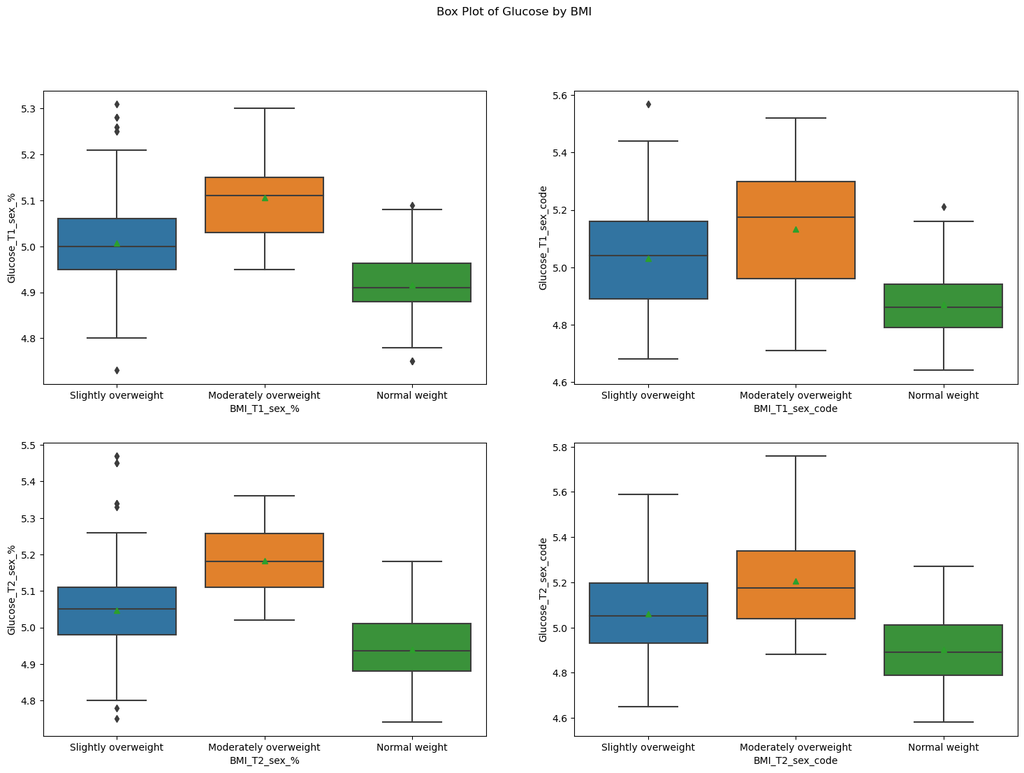

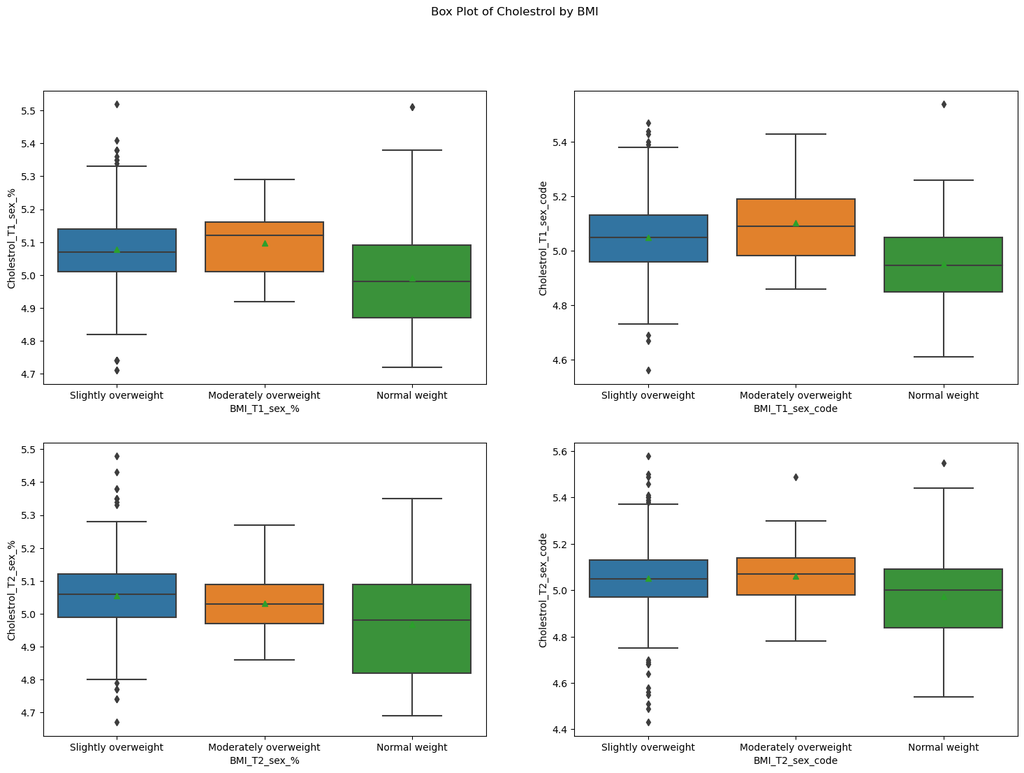

```python
def box_plot(target = 'Glucose'):
    '''
    This function visualize the Levene's test of homogeneity of variances by box plots
    '''
    fig, axes = plt.subplots(2, 2, figsize=(18, 12))

    if target =='Glucose':
        fig.suptitle('Box Plot of Glucose by BMI')

        data1 = [categorical_df['Glucose_T1_sex_%'][categorical_df['BMI_T1_sex_%'] == 'Normal weight'],
                     categorical_df['Glucose_T1_sex_%'][categorical_df['BMI_T1_sex_%'] == 'Slightly overweight'],
                     categorical_df['Glucose_T1_sex_%'][categorical_df['BMI_T1_sex_%'] == 'Moderately overweight']]

        data2 = [categorical_df['Glucose_T1_sex_code'][categorical_df['BMI_T1_sex_code'] == 'Normal weight'],
                     categorical_df['Glucose_T1_sex_code'][categorical_df['BMI_T1_sex_code'] == 'Slightly overweight'],
                     categorical_df['Glucose_T1_sex_code'][categorical_df['BMI_T1_sex_code'] == 'Moderately overweight']]

        data3 = [categorical_df['Glucose_T2_sex_%'][categorical_df['BMI_T2_sex_%'] == 'Normal weight'],
                     categorical_df['Glucose_T2_sex_%'][categorical_df['BMI_T2_sex_%'] == 'Slightly overweight'],
                     categorical_df['Glucose_T2_sex_%'][categorical_df['BMI_T2_sex_%'] == 'Moderately overweight']]

        data4 = [categorical_df['Glucose_T2_sex_code'][categorical_df['BMI_T2_sex_code'] == 'Normal weight'],
                     categorical_df['Glucose_T2_sex_code'][categorical_df['BMI_T2_sex_code'] == 'Slightly overweight'],
                     categorical_df['Glucose_T2_sex_code'][categorical_df['BMI_T2_sex_code'] == 'Moderately overweight']]

        sns.boxplot(data=categorical_df,ax=axes[0, 0],x = 'BMI_T1_sex_%',y='Glucose_T1_sex_%',showmeans= True)
        sns.boxplot(data=categorical_df,ax=axes[0, 1],x = 'BMI_T1_sex_code',y='Glucose_T1_sex_code',showmeans= True)
        sns.boxplot(data=categorical_df,ax=axes[1, 0],x = 'BMI_T2_sex_%',y='Glucose_T2_sex_%',showmeans= True)
        sns.boxplot(data=categorical_df,ax=axes[1, 1],x = 'BMI_T2_sex_code',y='Glucose_T2_sex_code',showmeans= True)

    if target == 'Cholestrol':
        fig.suptitle('Box Plot of Cholestrol by BMI')

        data1 = [categorical_df['Cholestrol_T1_sex_%'][categorical_df['BMI_T1_sex_%'] == 'Normal weight'],
                     categorical_df['Cholestrol_T1_sex_%'][categorical_df['BMI_T1_sex_%'] == 'Slightly overweight'],
                     categorical_df['Cholestrol_T1_sex_%'][categorical_df['BMI_T1_sex_%'] == 'Moderately overweight']]

        data2 = [categorical_df['Cholestrol_T1_sex_code'][categorical_df['BMI_T1_sex_code'] == 'Normal weight'],
                     categorical_df['Cholestrol_T1_sex_code'][categorical_df['BMI_T1_sex_code'] == 'Slightly overweight'],
                     categorical_df['Cholestrol_T1_sex_code'][categorical_df['BMI_T1_sex_code'] == 'Moderately overweight']]

        data3 = [categorical_df['Cholestrol_T2_sex_%'][categorical_df['BMI_T2_sex_%'] == 'Normal weight'],
                     categorical_df['Cholestrol_T2_sex_%'][categorical_df['BMI_T2_sex_%'] == 'Slightly overweight'],
                     categorical_df['Cholestrol_T2_sex_%'][categorical_df['BMI_T2_sex_%'] == 'Moderately overweight']]

        data4 = [categorical_df['Cholestrol_T2_sex_code'][categorical_df['BMI_T2_sex_code'] == 'Normal weight'],
                     categorical_df['Cholestrol_T2_sex_code'][categorical_df['BMI_T2_sex_code'] == 'Slightly overweight'],
                     categorical_df['Cholestrol_T2_sex_code'][categorical_df['BMI_T2_sex_code'] == 'Moderately overweight']]

        sns.boxplot(data=categorical_df,ax=axes[0, 0],x = 'BMI_T1_sex_%',y='Cholestrol_T1_sex_%',showmeans= True)
        sns.boxplot(data=categorical_df,ax=axes[0, 1],x = 'BMI_T1_sex_code',y='Cholestrol_T1_sex_code',showmeans= True)
        sns.boxplot(data=categorical_df,ax=axes[1, 0],x = 'BMI_T2_sex_%',y='Cholestrol_T2_sex_%',showmeans= True)
        sns.boxplot(data=categorical_df,ax=axes[1, 1],x = 'BMI_T2_sex_code',y='Cholestrol_T2_sex_code',showmeans= True)

    plt.show()

box_plot(target = 'Glucose')
box_plot(target = 'Cholestrol')
```

#### 4-3-3: ANOVA:

The assumptions of testing ANOVA are checked (Normality, Homogeneity test).

In terms of BMI effects on cholestrol, which have not equal variance, the Kruskal-Wallis test should be used.(Kruskal-Wallis test is the non-parametric version of the one-way ANOVA)

```python
def One_way_ANOVA():

    BMI_GLU_list = [['Glucose_T1_sex_%','BMI_T1_sex_%'],['Glucose_T2_sex_%','BMI_T2_sex_%'],
                    ['Glucose_T1_sex_code','BMI_T1_sex_code'],['Glucose_T2_sex_code','BMI_T2_sex_code']]

    for i, j in BMI_GLU_list:
            statistic, pvalue = stats.f_oneway (categorical_df[i][categorical_df[j] == 'Normal weight'],
                         categorical_df[i][categorical_df[j] == 'Slightly overweight'],
                         categorical_df[i][categorical_df[j] == 'Moderately overweight'])
            print (i,'_',j, ', P_value: ',pvalue)
            if pvalue<0.05:
                print ('pvalue is less than 0.05. There IS a statistically significant difference between the groups and their effects the Glucose \n')
            if pvalue>0.05:
                print ('pvalue is greater than 0.05. There is NOT a statistically significant difference between the groups and their effects the Glucose\n')

One_way_ANOVA()
```

```
Glucose_T1_sex_% _ BMI_T1_sex_% , P_value:  1.4458365961894108e-34
pvalue is less than 0.05. There IS a statistically significant difference between the groups and their effects the Glucose

Glucose_T2_sex_% _ BMI_T2_sex_% , P_value:  3.173153845329409e-35
pvalue is less than 0.05. There IS a statistically significant difference between the groups and their effects the Glucose

Glucose_T1_sex_code _ BMI_T1_sex_code , P_value:  2.716963495950963e-24
pvalue is less than 0.05. There IS a statistically significant difference between the groups and their effects the Glucose

Glucose_T2_sex_code _ BMI_T2_sex_code , P_value:  4.280384353185872e-24
pvalue is less than 0.05. There IS a statistically significant difference between the groups and their effects the Glucose
```

```python
def Kruskal_Wallis():

    BMI_CHO_list = [['Cholestrol_T1_sex_%','BMI_T1_sex_%'],['Cholestrol_T2_sex_%','BMI_T2_sex_%'],
                    ['Cholestrol_T1_sex_code','BMI_T1_sex_code'],['Cholestrol_T2_sex_code','BMI_T2_sex_code']]

    for i, j in BMI_CHO_list:
            statistic, pvalue = stats.kruskal (categorical_df[i][categorical_df[j] == 'Normal weight'],
                         categorical_df[i][categorical_df[j] == 'Slightly overweight'],
                         categorical_df[i][categorical_df[j] == 'Moderately overweight'])
            print (i,'_',j, ', P_value: ',pvalue)
            if pvalue<0.05:
                print ('pvalue is less than 0.05. There IS a statistically significant difference between the groups and their effects the Cholestrol \n')
            if pvalue>0.05:
                print ('pvalue is greater than 0.05. There is NOT a statistically significant difference between the groups and their effects the Cholestrol\n')

Kruskal_Wallis()
```

```
Cholestrol_T1_sex_% _ BMI_T1_sex_% , P_value:  2.440010174856798e-10
pvalue is less than 0.05. There IS a statistically significant difference between the groups and their effects the Cholestrol

Cholestrol_T2_sex_% _ BMI_T2_sex_% , P_value:  2.382354816110586e-05
pvalue is less than 0.05. There IS a statistically significant difference between the groups and their effects the Cholestrol

Cholestrol_T1_sex_code _ BMI_T1_sex_code , P_value:  6.356869655797237e-11
pvalue is less than 0.05. There IS a statistically significant difference between the groups and their effects the Cholestrol

Cholestrol_T2_sex_code _ BMI_T2_sex_code , P_value:  0.0008159199497611449
pvalue is less than 0.05. There IS a statistically significant difference between the groups and their effects the Cholestrol
```

## Part 5: Deduction:

#### 2- Is there any difference in the mean BMI values between the two types of gender seperation?

##### ans:

Based on the Normality check outcome and 2-sample t_test results; there is NO significant difference of mean BMI values between two gender seperation methods observed.

#### 3- Assess the effect of BMI on Glucose and Cholestrol separately?

##### ans:

Based on ANOVA and Kruskal_Wallis test, there IS a statistically significant difference between the groups of BMI and their effects the Glucose and Cholestrol. So, BMI has influence on Cholestrol and Glucose.